# Loans data: features exploration

Dzianis Sokalau

7/16/2017

Before we took a first look on the Lending club loans data. You can find information by the link bellow: https://dzianissokalau.github.io/projects/loans/1-loans-data-first-look.html

On this note I want to explore features usefull for loan evaluation.

The data is from https://www.kaggle.com/wendykan/lending-club-loan-data  
Original source is Lending Club: https://www.lendingclub.com/info/download-data.action

### What features we shouldn’t use for future model

The data contain a lot of features. Some of them are primary, some are the result of following calculations / evaluations. I’m not going to explore features that show loans’ evaluation since they are already the product of scorring calculated by others. Those features are “int_rate”, “grade” and “sub_grade”.

### Features

From various of features in the data set I would choose those which describe numbers (income, loan amount), loans category (purpose, term), borrower profile (public records, delinquencies, accounts etc), time (when loan was issued) and location (state).

### Purposes

Let’s begin from purposes.

```r
df %>%
  group_by(purpose) %>%
  summarise(prob = mean(result), count = n()) %>%
  arrange(desc(prob))
```

```
## # A tibble: 14 x 3
##               purpose      prob  count
##                 <chr>     <dbl>  <int>
##  1            wedding 0.8609272   1963
##  2                car 0.8582931   3726
##  3     major_purchase 0.8311748   6486
##  4        educational 0.8276923    325
##  5   home_improvement 0.8095664  15638
##  6        credit_card 0.8062208  52405
##  7           vacation 0.7963746   1655
##  8              house 0.7941860   1720
##  9   renewable_energy 0.7717391    276
## 10 debt_consolidation 0.7713001 156572
## 11            medical 0.7631931   2994
## 12              other 0.7592555  14937
## 13             moving 0.7529357   2129
## 14     small_business 0.6811302   4955
```

The most stable are wedding and car loans (more than 85% of them are good). Hovewer thay take around 2% of all loans in the sample. Debt consolidation is the most frequent purpose of debts it takes about 59% with average share of good loans 77%. Loans for small business are the worst in the sample in terms returning (only 68% of them is paid by borrowers). As we can see purpose is a good feature to use. Depands on it probability of loan to be paid vary from 68% to 86%.

It can be interesting to look on interaction between amount, purposes and loan status.

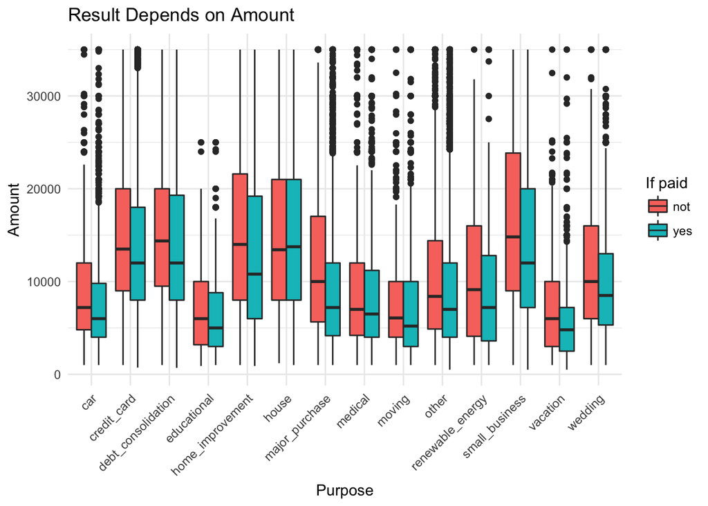

```r
ggplot(df, aes(as.factor(purpose), loan_amnt, fill = factor(result, labels = c("not", "yes")))) +
  geom_boxplot() +
  labs(title = "Result Depends on Amount", x = "Purpose", y = "Amount") +
  guides(fill=guide_legend(title="If paid")) +
  theme_minimal() +
  theme(axis.text.x=element_text(angle=45,hjust=1))
```

Bad loans are usualy have higher amount depends on purpose than good ones.

### States

addr_state - The state provided by the borrower in the loan application.

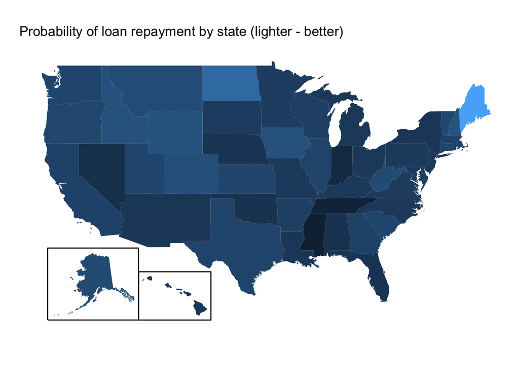

```r
# Let's create table with probability of loan repayment by state first
states_prob <- df %>%
  group_by(addr_state) %>%
  summarise(prob = mean(result), count = n()) %>%
  arrange(desc(prob))

# Also we need to add full state names (for map drawing)
states_prob <- merge(states_prob, states_dict, by = "addr_state", all.x = T)

# Now let's map it
ggplot(states_prob, aes(map_id = state)) +
  geom_map(aes(fill = prob), map = fifty_states) +
  expand_limits(x = fifty_states$long, y = fifty_states$lat) +
  coord_map() +
  scale_x_continuous(breaks = NULL) +
  scale_y_continuous(breaks = NULL) +
  labs(title = "Probability of loan repayment by state (lighter - better)", x = "", y = "") +
  theme(legend.position = "None",
        panel.background = element_blank()) +
  fifty_states_inset_boxes()
```

Some states some states have higher (maximum is 100%) probability of loan repayment and some lower (minimum is 69%). A good idea is generalizing States in the groups (for future modelling).

```r
df <- merge(df,
            data.frame(addr_state = states_prob[,1], state_group = states_prob[,2]),
            by = "addr_state", all.x = T)

# spliting by 3 groups
df$state_group <- factor(cut2(unlist(df$state_group), g=3),
                         labels = c("low", "medium", "high"))

# checking
df %>%
  group_by(state_group) %>%
  summarise(prob = mean(result), count = n())
```

```
## # A tibble: 3 x 3
##   state_group      prob  count
##        <fctr>     <dbl>  <int>
## 1         low 0.7580926  90824
## 2      medium 0.7860953 106094
## 3        high 0.8055124  68863
```

Not bad split I guess.

### Home ownership

home_ownership - The home ownership status provided by the borrower during registration.

```r
df %>%
  group_by(home_ownership) %>%
  summarise(prob = mean(result), count = n()) %>%
  arrange(desc(prob))
```

```
## # A tibble: 6 x 3
##   home_ownership      prob  count
##            <chr>     <dbl>  <int>
## 1            ANY 1.0000000      1
## 2           NONE 0.8372093     43
## 3          OTHER 0.8085106    141
## 4       MORTGAGE 0.8051948 130361
## 5            OWN 0.7705839  23307
## 6           RENT 0.7562540 111928
```

Renters and home owners are less likely to return loan. Since there are several categories with small number of observations I would like to union them with mortgage.

```r
df[df$home_ownership %in% c("MORTGAGE", "OTHER", "NONE", "ANY"), "home_ownership"] <- "OTHER"
df %>%
  group_by(home_ownership) %>%
  summarise(prob = mean(result), count = n()) %>%
  arrange(desc(prob))
```

```
## # A tibble: 3 x 3
##   home_ownership      prob  count
##            <chr>     <dbl>  <int>
## 1          OTHER 0.8052104 130546
## 2            OWN 0.7705839  23307
## 3           RENT 0.7562540 111928
```

### Term

term - the number of payments on the loan. Values are in months and can be either 36 or 60.

```r
df %>%
  group_by(term) %>%
  summarise(prob = mean(result), count = n()) %>%
  arrange(desc(prob))
```

```
## # A tibble: 2 x 3
##        term      prob  count
##       <chr>     <dbl>  <int>
## 1 36 months 0.8198426 204399
## 2 60 months 0.6540680  61382
```

The shorter term is the more likely loan to be paid.

### Employment length

```r
df %>%
  group_by(emp_length) %>%
  summarise(prob = mean(result), count = n()) %>%
  arrange(desc(prob))
```

```
## # A tibble: 12 x 3
##    emp_length      prob count
##         <chr>     <dbl> <int>
##  1    4 years 0.7925598 16935
##  2    2 years 0.7905753 24701
##  3    5 years 0.7893311 18821
##  4  10+ years 0.7891557 80780
##  5    3 years 0.7865347 21418
##  6     1 year 0.7836191 17728
##  7    6 years 0.7816166 15427
##  8    7 years 0.7785613 14749
##  9    8 years 0.7771543 12475
## 10   < 1 year 0.7746146 21989
## 11    9 years 0.7735081 10071
## 12        n/a 0.6898100 10687
```

“n/a” (probably means person is unemployed) in emp_length reduces chances for loan repayment significantly. Let’s create an additional variable “emp_na” (1 if emp_length == “n/a”, and 0 if emp_length != “n/a”).

```r
df$emp_na <- 0
df[df$emp_length == "n/a", "emp_na"] <- 1
```

It probably makes sence to convert emp_length to integer.

```r
df[df$emp_length == "n/a", "emp_length"] <- "0"
regexp <- "[[:digit:]]+"
df$emp_length <- as.integer(str_extract(df$emp_length, regexp))

df %>%
  group_by(emp_length) %>%
  summarise(prob = mean(result), count = n()) %>%
  arrange(emp_length)
```

```
## # A tibble: 11 x 3
##    emp_length      prob count
##         <int>     <dbl> <int>
##  1          0 0.6898100 10687
##  2          1 0.7786338 39717
##  3          2 0.7905753 24701
##  4          3 0.7865347 21418
##  5          4 0.7925598 16935
##  6          5 0.7893311 18821
##  7          6 0.7816166 15427
##  8          7 0.7785613 14749
##  9          8 0.7771543 12475
## 10          9 0.7735081 10071
## 11         10 0.7891557 80780
```

### Verification status

verification_status - indicates if income was verified by LC.

```r
df %>%
  group_by(verification_status) %>%
  summarise(prob = mean(result), count = n()) %>%
  arrange(desc(prob))
```

```
## # A tibble: 3 x 3
##   verification_status      prob count
##                 <chr>     <dbl> <int>
## 1        Not Verified 0.8311221 88863
## 2     Source Verified 0.7610167 79198
## 3            Verified 0.7531314 97720
```

The interesting thing is that “Not Verified” in verification_status increases chances for loan repayment.

### Annual income

annual_inc - the self-reported annual income provided by the borrower during registration.

```r
df %>%
  group_by(annual_inc) %>%
  summarise(prob = mean(result), count = n()) %>%
  arrange(desc(count))
```

```
## # A tibble: 20,264 x 3
##    annual_inc      prob count
##         <dbl>     <dbl> <int>
##  1      60000 0.7556868 10331
##  2      50000 0.7596780  9067
##  3      65000 0.7714477  7460
##  4      40000 0.7248313  7261
##  5      70000 0.7794033  6972
##  6      45000 0.7461382  6862
##  7      75000 0.7948124  6477
##  8      80000 0.7897276  6425
##  9      55000 0.7683107  6103
## 10      90000 0.8116298  4884
## # ... with 20,254 more rows
```

Let’s take a look on imcome depends on loan purpose and result.

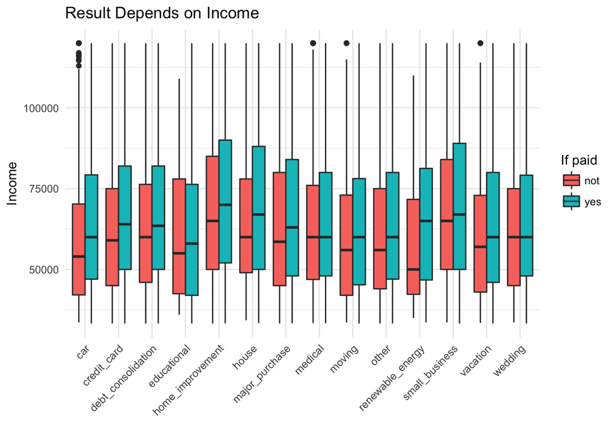

```r
ggplot(df, aes(as.factor(purpose), annual_inc, fill = factor(result, labels = c("not", "yes")))) +
  geom_boxplot() +
  labs(title = "Result Depends on Income", x = "", y = "Income") +
  guides(fill=guide_legend(title="If paid")) +
  scale_y_continuous(limits = quantile(df$annual_inc, c(0.1, 0.9))) +
  theme_minimal() +
  theme(axis.text.x=element_text(angle=45,hjust=1))
```

Almost for all purposes income for those who paid loan is higher.

### dti

dti is a ratio calculated using the borrower’s total monthly debt payments on the total debt obligations, excluding mortgage and the requested LC loan, divided by the borrower’s self-reported. monthly income. dti combines information considered above (loan’s amount, borrower’s income and term) but in the same time it is a very good indicator of borrower’s financial health. The hypothesis is the higher dti is the lower probability successful loan repayment. Let’s check it.

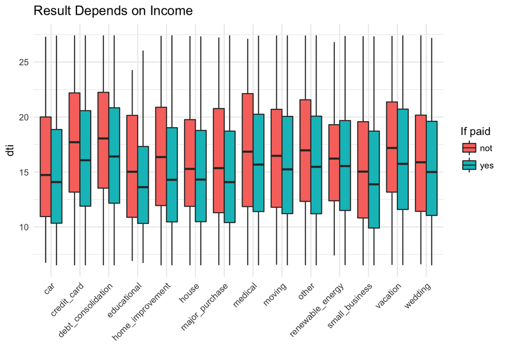

```r
ggplot(df, aes(as.factor(purpose), dti, fill = factor(result, labels = c("not", "yes")))) +
  geom_boxplot() +
  labs(title = "Result Depends on Income", x = "", y = "dti") +
  guides(fill=guide_legend(title="If paid")) +
  scale_y_continuous(limits = quantile(df$dti, c(0.1, 0.9))) +
  theme_minimal() +
  theme(axis.text.x=element_text(angle=45,hjust=1))
```

### emp_title

emp_title - the job title supplied by the Borrower when applying for the loan. This time I’m not going to explore job titles since there are too many variants. It could be a topic for an additional research. But I noticed that empty job title can reduce chanses of successful loan repayment, so let’s explore this feature.

```r
df$jobtitle_empty <- 0
df[is.na(df$emp_title) == T, "jobtitle_empty"] <- 1

df %>%
  group_by(jobtitle_empty) %>%
  summarise(prob = mean(result), count = n()) %>%
  arrange(desc(count))
```

```
## # A tibble: 2 x 3
##   jobtitle_empty      prob  count
##            <dbl>     <dbl>  <int>
## 1              0 0.7858438 250985
## 2              1 0.7088402  14796
```

### desc

desc - loan description provided by the borrower. Alongside with jobtitle I’m not going to do a research for description content. But let’s try to do same exercize we did with job title.

```r
df$desc_empty <- 0
df[is.na(df$desc) == T, "desc_empty"] <- 1

df %>%
  group_by(desc_empty) %>%
  summarise(prob = mean(result), count = n()) %>%
  arrange(desc(count))
```

```
## # A tibble: 2 x 3
##   desc_empty      prob  count
##        <dbl>     <dbl>  <int>
## 1          1 0.7637294 176446
## 2          0 0.8167683  89335
```

Not bad split too. Empty descriprion decreases chance of successful loan repayment.

### issue_d

issue_d - the month which the loan was funded. On the first sight it might seem a crazy idea but what if month realy impact on quality of loan.

```r
df$issue_month <- substr(df$issue_d, 1, 3)

df %>%
  group_by(issue_month) %>%
  summarise(prob = mean(result), count = n()) %>%
  arrange(desc(prob))
```

```
## # A tibble: 12 x 3
##    issue_month      prob count
##          <chr>     <dbl> <int>
##  1         Dec 0.8088041 18923
##  2         Sep 0.7976498 19743
##  3         Nov 0.7918473 22839
##  4         Aug 0.7894454 22303
##  5         Jan 0.7835932 23539
##  6         Oct 0.7823333 27317
##  7         Mar 0.7773227 20267
##  8         Jul 0.7719513 26183
##  9         Apr 0.7712872 22631
## 10         Jun 0.7711200 20928
## 11         Feb 0.7706749 19069
## 12         May 0.7671401 22039
```

As we can see the variation of probabilities isn’t very big but still exists.

### open_acc and total_acc

open_acc - the number of open credit lines in the borrower’s credit file. total_acc - the total number of credit lines currently in the borrower’s credit file. Obviously number of accounts in borrower’s file will hardly give us good probability split. But if we will calculate share of active accounts in total accaunts it will give us new good feature.

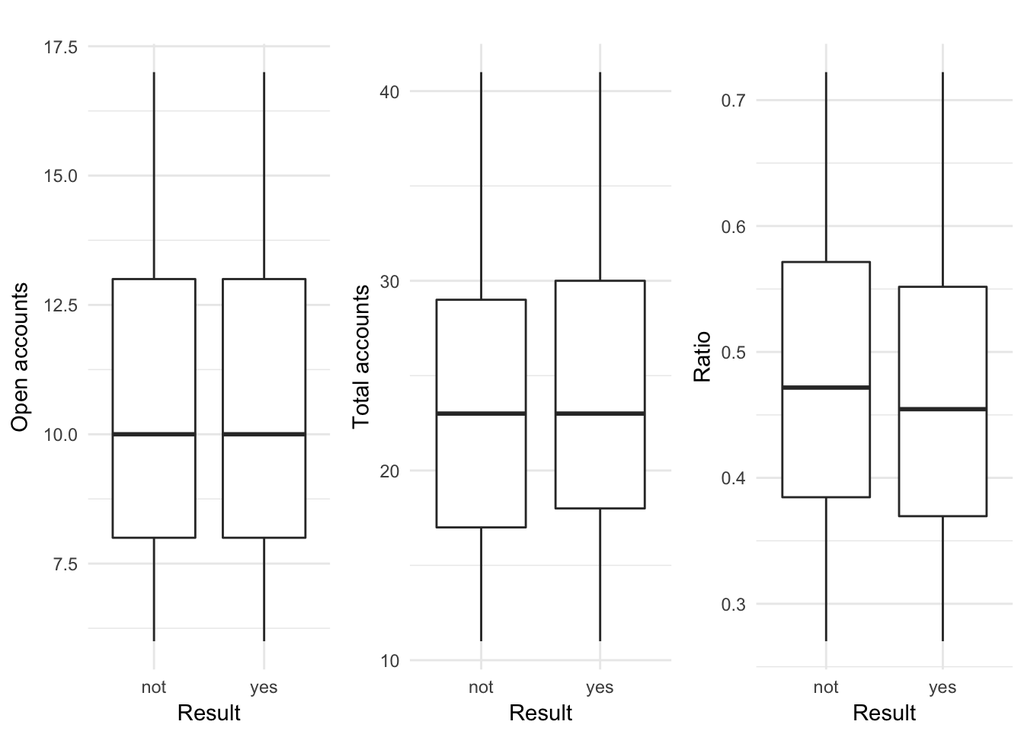

```r
df$act_tot_acc <- df$open_acc / df$total_acc

p1 <- ggplot(df, aes(factor(result, labels = c("not", "yes")), open_acc)) +
        geom_boxplot() +
        labs(title = "", x = "Result", y = "Open accounts") +
        scale_y_continuous(limits = quantile(df$open_acc, c(0.1, 0.9))) +
        theme_minimal()

p2 <- ggplot(df, aes(factor(result, labels = c("not", "yes")), total_acc)) +
        geom_boxplot() +
        labs(title = "", x = "Result", y = "Total accounts") +
        scale_y_continuous(limits = quantile(df$total_acc, c(0.1, 0.9))) +
        theme_minimal()

p3 <- ggplot(df, aes(factor(result, labels = c("not", "yes")), act_tot_acc)) +
        geom_boxplot() +
        labs(title = "", x = "Result", y = "Ratio") +
        scale_y_continuous(limits = quantile(df$act_tot_acc, c(0.1, 0.9))) +
        theme_minimal()

grid.arrange(p1, p2, p3, ncol = 3, nrow = 1)
```

It isn’t super high improvement but median of ratio is a little bit different between paid and not paid loans.

### delinq_2yrs

delinq_2yrs - the number of 30+ days past-due incidences of delinquency in the borrower’s credit file for the past 2 years.

```r
df %>%
  group_by(delinq_2yrs) %>%
  summarise(prob = mean(result), count = n()) %>%
  arrange(desc(count))
```

```
## # A tibble: 24 x 3
##    delinq_2yrs      prob  count
##          <int>     <dbl>  <int>
##  1           0 0.7869112 222128
##  2           1 0.7641884  30007
##  3           2 0.7424893   8388
##  4           3 0.7180946   2813
##  5           4 0.7238347   1137
##  6           5 0.7118644    590
##  7           6 0.7191781    292
##  8           7 0.6751592    157
##  9           8 0.7708333     96
## 10           9 0.7321429     56
## # ... with 14 more rows
```

Basicly many delinquences in past isn’t a good sing.

### inq_last_6mths

inq_last_6mths - the number of inquiries in past 6 months (excluding auto and mortgage inquiries).

```r
df %>%
  group_by(inq_last_6mths) %>%
  summarise(prob = mean(result), count = n()) %>%
  arrange(desc(count))
```

```
## # A tibble: 9 x 3
##   inq_last_6mths      prob  count
##            <int>     <dbl>  <int>
## 1              0 0.8009770 129995
## 2              1 0.7733239  76563
## 3              2 0.7580441  36424
## 4              3 0.7384909  16791
## 5              4 0.7328750   3927
## 6              5 0.7322888   1468
## 7              6 0.6921676    549
## 8              7 0.7391304     46
## 9              8 0.7777778     18
```

The more inquiries for past 6 months you had the less likely you will pay loan successfully.

### tot_cur_bal

tot_cur_bal - total current balance of all accounts

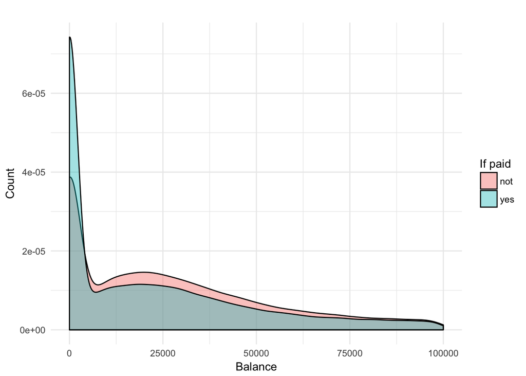

```r
# let's convert n/a to 0 first and convert variable to numeric
df[is.na(df$tot_cur_bal) == T, "tot_cur_bal"] <- 0
df$tot_cur_bal <- as.numeric(df$tot_cur_bal)

# now the data is ready to be vizualized
ggplot(df, aes(tot_cur_bal, fill = factor(result, labels = c("not", "yes")))) +
  geom_density(alpha = 0.4) +
  guides(fill=guide_legend(title="If paid")) +
  xlim(0,100000) +
  labs(title = "", x = "Balance", y = "Count") +
  theme_minimal()
```

n/a (or 0) in tot_cur_bal increasing chances of successful loan repayment. Let’s create an additional variable to split zero and nonzero values.

```r
df$zero_bal <- 0
df[df$tot_cur_bal == 0, 'zero_bal'] <- 1

# and we've got following
df %>%
  group_by(zero_bal) %>%
  summarise(prob = mean(result), count = n()) %>%
  arrange(desc(prob))
```

```
## # A tibble: 2 x 3
##   zero_bal      prob  count
##      <dbl>     <dbl>  <int>
## 1        1 0.8407825  63900
## 2        0 0.7628108 201881
```

# open_il_6m, open_il_12m and open_il_24m

open_il_6m - number of currently active installment trades. open_il_12m - number of installment accounts opened in past 12 months. open_il_24m - number of installment accounts opened in past 24 months.

There are small group of borrowers with currently active or opened installment accounts in past 24 months.

```r
nrow(df[is.na(df$open_il_6m) == F | is.na(df$open_il_12m) == F | is.na(df$open_il_24m) == F, ])
```

```
## [1] 144
```

let’s create new variable shows if there were any installment accounts oppened in past.

```r
df$open_il <- 0
df[is.na(df$open_il_6m) == F | is.na(df$open_il_12m) == F | is.na(df$open_il_24m) == F, "open_il"] <- 1

df %>%
  group_by(open_il) %>%
  summarise(prob = mean(result), count = n()) %>%
  arrange(desc(prob))
```

```
## # A tibble: 2 x 3
##   open_il      prob  count
##     <dbl>     <dbl>  <int>
## 1       1 1.0000000    144
## 2       0 0.7814386 265637
```

### pub_rec

pub_rec - number of derogatory public records.

```r
df %>%
  group_by(pub_rec) %>%
  summarise(prob = mean(result), count = n()) %>%
  arrange(pub_rec)
```

```
## # A tibble: 14 x 3
##    pub_rec      prob  count
##      <int>     <dbl>  <int>
##  1       0 0.7836315 232654
##  2       1 0.7708176  29182
##  3       2 0.7451264   2770
##  4       3 0.7447090    756
##  5       4 0.6899563    229
##  6       5 0.6568627    102
##  7       6 0.6818182     44
##  8       7 0.7368421     19
##  9       8 0.8888889      9
## 10       9 0.4285714      7
## 11      10 1.0000000      5
## 12      11 0.5000000      2
## 13      12 0.0000000      1
## 14      15 1.0000000      1
```

As was expected high number of public records may decrease chances of successful loan repayment

In the note abowe I have considered features which can be used for borrowers evaluation / clusterisation. In the next notes I will try to build a pedictive model based on this features.

### TBC

You can find me and check for updates  
here: https://www.linkedin.com/in/dzianis-sokalau-83454a3b/  
or here: https://twitter.com/ptyshka